# analysis3week9

This file uses processed_data file.

# Load libraries

```r
library(tidyverse)
```

```r
library(dplyr)
library(broom)
library(ggplot2)
library(rsample) #for training and testing
library(tidymodels) #for modeling and recipes
```

Locate file and download data

```r
data_location <- here::here("data","processed_data","processed_data.rds")
dat <- readRDS(data_location)
```

"Write code that takes the data and splits it randomly into a *train and test* that, following for instance the example in the Data Splitting section of the Get Started tidymodels tutorial."

- Training set is used to fit the model
- Testing set is used for evaluation
- Use rsample package ot create an object that tells how to split the data
- use rsample to then create dataframes for training and testing sets

```r
#Fic the random numbers by setting the seed, allowing the analysis to be reproducible when random numbers are used.
#We can pick any random number (?)
set.seed(48)

#Put 3/4 data into the training set
data_split <- initial_split(dat, prop =3/4)

#Create data frames for the two sets:
train_data <- training(data_split)
test_data <- testing(data_split)
```

Congratulations! We have created our training and testing data sets.

We are focusing on our *categorical outcome of interest*, which was *nausea*.We are fitting this outcome to all predictors, starting with categorical.

*Creating a Recipe.* A recipe is a description of the steps to be applied to a data set in order to prepare it for analysis. https://recipes.tidymodels.org/reference/recipe.html

```r
data_recipe <- recipe(Nausea ~ ., data = train_data) #First part is the formula: Nausea is the outcome of interest and to the right of tilde are predictors (a period indicates all other variables). Second part is the data used in the model (usually training set)
```

Set a model. Set a logistical model to a categorical outcome.

```r
log_mod <- logistic_reg() %>%
  set_engine("glm") %>%
  set_mode("classification")
```

Now we want to process the recipe using the training set, apply the recipe to the training set, and apply the recipe to the test set. To simplify the process, we use *workflows package* from tinymodels.

```r
nausea_wflow <- workflow() %>%
  add_model(log_mod) %>%
  add_recipe(data_recipe)

nausea_wflow
```

```
## ══ Workflow ════════════════════════════════════════════════════════════════════
## Preprocessor: Recipe
## Model: logistic_reg()
##
## ── Preprocessor ────────────────────────────────────────────────────────────────
## 0 Recipe Steps
##
## ── Model ───────────────────────────────────────────────────────────────────────
## Logistic Regression Model Specification (classification)
##
## Computational engine: glm
```

In a single fucntion, we can prepare the recipe and train the model from the resulting predictors:

```r
nausea_fit <- nausea_wflow %>%
  fit(data=train_data)

#the following extracts the finalized recipe and fitted model objects inside.
nausea_fit %>% extract_fit_parsnip() %>%
  tidy()
```

```
## # A tibble: 38 × 5
##    term                 estimate std.error statistic p.value
##    <chr>                   <dbl>     <dbl>     <dbl>   <dbl>
##  1 (Intercept)             7.68      9.23      0.832 0.405
##  2 SwollenLymphNodesYes   -0.440     0.236    -1.87  0.0619
##  3 ChestCongestionYes      0.589     0.260     2.27  0.0234
##  4 ChillsSweatsYes         0.318     0.337     0.944 0.345
##  5 NasalCongestionYes      0.874     0.324     2.70  0.00700
##  6 CoughYNYes             -0.468     0.617    -0.758 0.448
##  7 SneezeYes               0.211     0.253     0.832 0.405
##  8 FatigueYes              0.403     0.451     0.895 0.371
##  9 SubjectiveFeverYes      0.386     0.266     1.45  0.146
## 10 HeadacheYes             0.229     0.339     0.676 0.499
## # … with 28 more rows
```

Now we are using the trained workflow to predict with the unseen test data. For this, we use the single call "predict()".

```r
predict(nausea_fit, test_data)
```

```
## # A tibble: 183 × 1
##    .pred_class
##    <fct>
##  1 No
##  2 Yes
##  3 Yes
##  4 No
##  5 No
##  6 Yes
##  7 No
##  8 No
##  9 No
## 10 No
## # … with 173 more rows
```

The output from predict() returns Yes or No. To get back predicted class probabilities, we can specify "type = "prob"" when we use predict() or augment().

```r
nausea_aug_train <- augment(nausea_fit, train_data)
#This produces a tibble with predicted class probabilities.

nausea_aug_train %>% select(Nausea, .pred_Yes, .pred_No)
```

```
## # A tibble: 547 × 3
##    Nausea .pred_Yes .pred_No
##    <fct>      <dbl>    <dbl>
##  1 No        0.477     0.523
##  2 No        0.882     0.118
##  3 No        0.291     0.709
##  4 No        0.765     0.235
##  5 No        0.0319    0.968
##  6 Yes       0.407     0.593
##  7 No        0.101     0.899
##  8 Yes       0.179     0.821
##  9 Yes       0.750     0.250
## 10 Yes       0.836     0.164
## # … with 537 more rows
```

*Plotting* Now we use the area under the ROC curve as our metric, computed using roc_curve() and roc_auc() from yardstick package. ROC helps determine what probability cutoff should be used.Commonly, the area under the ROC curve (AUC) is used to evaluate models. If the best model immediately proceeds to the upper left corner, the area under this curve would be one while the poor model would produce an AUC in the neighborhood of 0.50. Then, calculate the area under the ROC curve (AUC).

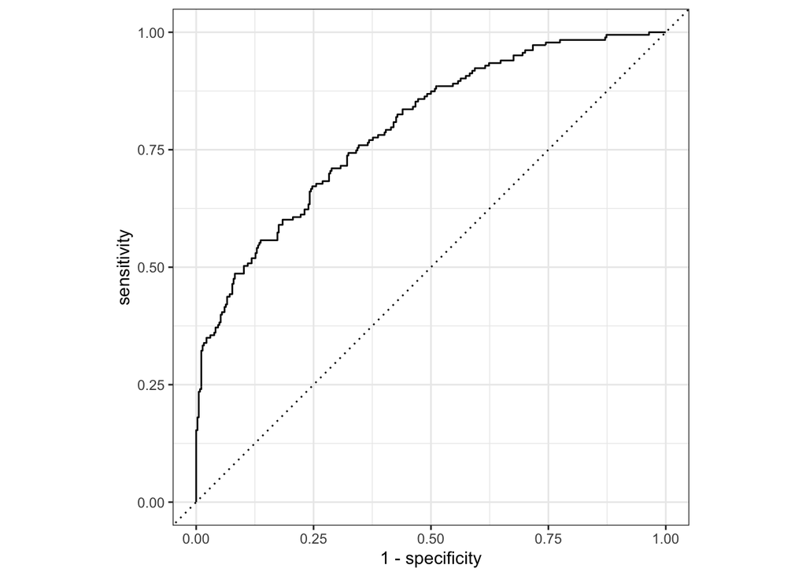

```r
nausea_roc_train <- nausea_aug_train %>% roc_curve(truth = Nausea, .pred_Yes, event_level = "second") %>% autoplot() #**Why is event level second?
nausea_roc_train
```

```r
nausea_auc_train <- nausea_aug_train %>% roc_auc(truth = Nausea, .pred_Yes, event_level = "second")
nausea_auc_train
```

```
## # A tibble: 1 × 3
##   .metric .estimator .estimate
##   <chr>   <chr>          <dbl>
## 1 roc_auc binary         0.797
```

Now test with the *test data*. Determine predictions.

```r
nausea_aug_test <- augment(nausea_fit, test_data)
#This produces a tibble with predicted class probabilities.

nausea_aug_test %>% select(Nausea, .pred_Yes, .pred_No)
```

```
## # A tibble: 183 × 3
##    Nausea .pred_Yes .pred_No
##    <fct>      <dbl>    <dbl>
##  1 No        0.173     0.827
##  2 Yes       0.821     0.179
##  3 No        0.500     0.500
##  4 No        0.381     0.619
##  5 No        0.105     0.895
##  6 No        0.686     0.314
##  7 No        0.195     0.805
##  8 No        0.174     0.826
##  9 No        0.0897    0.910
## 10 Yes       0.192     0.808
## # … with 173 more rows
```

*Plotting* Plot the test data using the model. Then, calculate the area under the ROC curve (AUC).

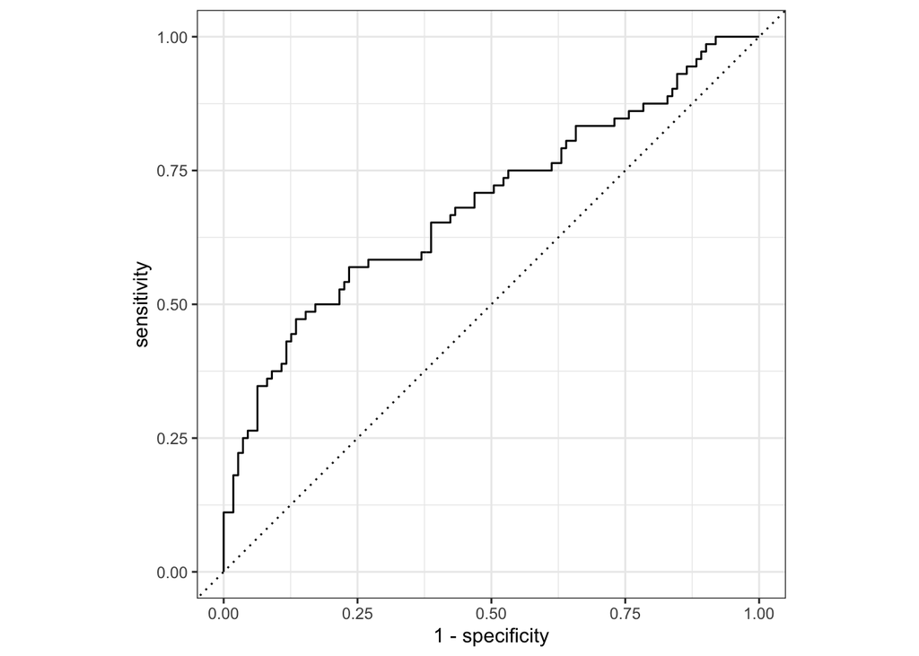

```r
nausea_roc_test <- nausea_aug_test %>% roc_curve(truth = Nausea, .pred_Yes, event_level = "second") %>% autoplot() #**Why is event level second?
nausea_roc_test
```

```r
nausea_auc_test <- nausea_aug_test %>% roc_auc(truth = Nausea, .pred_Yes, event_level = "second")
nausea_auc_test
```

```
## # A tibble: 1 × 3
##   .metric .estimator .estimate
##   <chr>   <chr>          <dbl>
## 1 roc_auc binary         0.686
```

The area under the curve is about 0.686, so the model might be useful. *Should this number be closer to that of the training data??*

Let’s re-do the fitting but now with a model that only fits the main predictor to the categorical outcome.

```r
data_recipe_nose <- recipe(Nausea ~ RunnyNose, data = train_data)
```

Set a model again. Set a logistical model to a categorical outcome.

```r
log_mod_nose <- logistic_reg() %>%
  set_engine("glm") %>%
  set_mode("classification")
```

Now we want to process the recipe using the training set, apply the recipe to the training set, and apply the recipe to the test set. To simplify the process, we use *workflows package* from tinymodels.

```r
nausea_nose_wflow <- workflow() %>%
  add_model(log_mod_nose) %>%
  add_recipe(data_recipe_nose)

nausea_nose_wflow
```

```
## ══ Workflow ════════════════════════════════════════════════════════════════════
## Preprocessor: Recipe
## Model: logistic_reg()
##
## ── Preprocessor ────────────────────────────────────────────────────────────────
## 0 Recipe Steps
##
## ── Model ───────────────────────────────────────────────────────────────────────
## Logistic Regression Model Specification (classification)
##
## Computational engine: glm
```

In a single function, we can prepare the recipe and train the model from the resulting predictors:

```r
nausea_nose_fit <- nausea_nose_wflow %>%
  fit(data=train_data)

#the following extracts the finalized recipe and fitted model objects inside.
nausea_nose_fit %>% extract_fit_parsnip() %>%
  tidy()
```

```
## # A tibble: 2 × 5
##   term         estimate std.error statistic   p.value
##   <chr>           <dbl>     <dbl>     <dbl>     <dbl>
## 1 (Intercept)  -0.684       0.164   -4.17   0.0000299
## 2 RunnyNoseYes -0.00502     0.197   -0.0255 0.980
```

Now we are using the trained workflow to predict with the unseen test data. For this, we use the single call "predict()".

```r
predict(nausea_nose_fit, test_data)
```

```
## # A tibble: 183 × 1
##    .pred_class
##    <fct>
##  1 No
##  2 No
##  3 No
##  4 No
##  5 No
##  6 No
##  7 No
##  8 No
##  9 No
## 10 No
## # … with 173 more rows
```

The output from predict() returns Yes or No. To get back predicted class probabilities, we can specify "type = "prob"" when we use predict() or augment().

```r
nausea_nose_aug_train <- augment(nausea_nose_fit, train_data, type = "prob")

nausea_nose_aug_train
```

```
## # A tibble: 547 × 35
##    SwollenLymphNodes ChestCongestion ChillsSweats NasalCongestion CoughYN Sneeze
##    <fct>             <fct>           <fct>        <fct>           <fct>   <fct>
##  1 Yes               Yes             Yes          Yes             Yes     Yes
##  2 Yes               Yes             No           Yes             Yes     Yes
##  3 No                No              Yes          Yes             Yes     Yes
##  4 No                Yes             Yes          Yes             Yes     Yes
##  5 Yes               No              Yes          No              Yes     No
##  6 No                Yes             Yes          Yes             Yes     Yes
##  7 No                No              Yes          Yes             Yes     No
##  8 Yes               Yes             Yes          Yes             Yes     No
##  9 Yes               Yes             Yes          Yes             Yes     No
## 10 No                No              Yes          Yes             No      No
## # … with 537 more rows, and 29 more variables: Fatigue <fct>,
## #   SubjectiveFever <fct>, Headache <fct>, Weakness <fct>, WeaknessYN <fct>,
## #   CoughIntensity <fct>, CoughYN2 <fct>, Myalgia <fct>, MyalgiaYN <fct>,
## #   RunnyNose <fct>, AbPain <fct>, ChestPain <fct>, Diarrhea <fct>,
## #   EyePn <fct>, Insomnia <fct>, ItchyEye <fct>, Nausea <fct>, EarPn <fct>,
## #   Hearing <fct>, Pharyngitis <fct>, Breathless <fct>, ToothPn <fct>,
## #   Vision <fct>, Vomit <fct>, Wheeze <fct>, BodyTemp <dbl>, …
```

```r
#This produces a tibble with predicted class probabilities.
```

Now we use the area under the ROC curve as our metric, computed using roc_curve() and roc_auc() from yardstick package. ROC helps determine what probability cutoff should be used.Commonly, the area under the ROC curve (AUC) is used to evaluate models. If the best model immediately proceeds to the upper left corner, the area under this curve would be one while the poor model would produce an AUC in the neighborhood of 0.50.

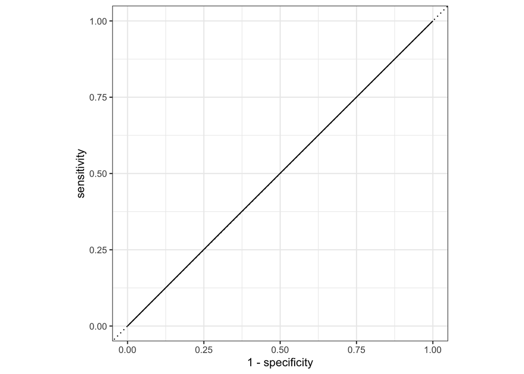

```r
nausea_nose_roc_train <- nausea_nose_aug_train %>% roc_curve(truth = Nausea, .pred_Yes, event_level = "second") %>% autoplot()

nausea_nose_roc_train
```

This is almost perfectly 0.5. This means the model is no good.

Calculating the area under the curve:

```r
nausea_nose_auc_train <- nausea_nose_aug_train %>% roc_auc(truth = Nausea, .pred_Yes, event_level = "second")

nausea_nose_auc_train
```

```
## # A tibble: 1 × 3
##   .metric .estimator .estimate
##   <chr>   <chr>          <dbl>
## 1 roc_auc binary         0.501
```

The value of 0.501 reinforces this: the model is no good.

First we predict the probabilities

```r
predict(nausea_nose_fit, test_data, type = "prob")
```

```
## # A tibble: 183 × 2
##    .pred_No .pred_Yes
##       <dbl>     <dbl>
##  1    0.666     0.334
##  2    0.666     0.334
##  3    0.665     0.335
##  4    0.665     0.335
##  5    0.666     0.334
##  6    0.666     0.334
##  7    0.666     0.334
##  8    0.666     0.334
##  9    0.665     0.335
## 10    0.666     0.334
## # … with 173 more rows
```

Now we use augment to turn this into a data frame.

```r
nausea_nose_aug_test <- augment(nausea_nose_fit, test_data)
nausea_nose_aug_test %>% select(Nausea, .pred_Yes, .pred_No)
```

```
## # A tibble: 183 × 3
##    Nausea .pred_Yes .pred_No
##    <fct>      <dbl>    <dbl>
##  1 No         0.334    0.666
##  2 Yes        0.334    0.666
##  3 No         0.335    0.665
##  4 No         0.335    0.665
##  5 No         0.334    0.666
##  6 No         0.334    0.666
##  7 No         0.334    0.666
##  8 No         0.334    0.666
##  9 No         0.335    0.665
## 10 Yes        0.334    0.666
## # … with 173 more rows
```

Plot as ROC, then calculate the AUC (area under curve)

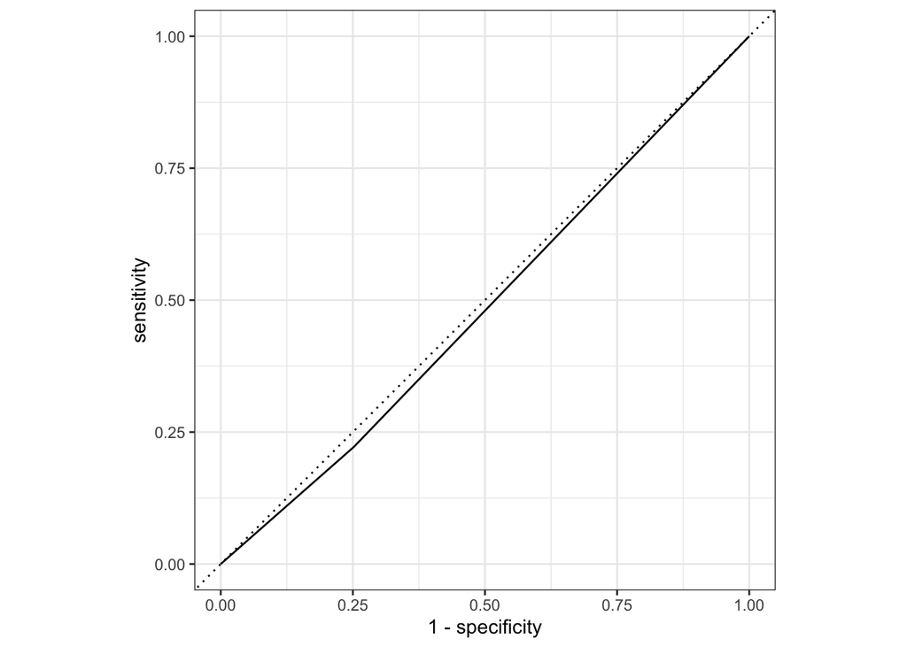

```r
nausea_nose_roc_test <- nausea_nose_aug_test %>% roc_curve(truth = Nausea, .pred_Yes, event_level = "second") %>% autoplot()

nausea_nose_roc_test
```

```r
nausea_nose_auc_test <- nausea_nose_aug_test %>% roc_auc(truth = Nausea, .pred_Yes, event_level = "second")

nausea_nose_auc_test
```

```
## # A tibble: 1 × 3
##   .metric .estimator .estimate
##   <chr>   <chr>          <dbl>
## 1 roc_auc binary         0.485
```

The area under the curve is 0.48, which is pretty close to the trained value. Still, this is not a good model.

# Nicholas' Code Starts Here

```r
# Creates a simple recipe that fits our continuous outcome of interest to all predictors
bodytmp_rec <-
  recipe(BodyTemp ~ ., data = train_data)

# Set a model as we did in the previous exercise
lr_mod <-
  linear_reg() %>%
  set_engine("lm")


# Use the workflow() package to create a
# simple workflow that fits a linear model
# to all predictors using the glm function
bodytmp_wflow <-
  workflow() %>%
  add_model(lr_mod) %>%
  add_recipe(bodytmp_rec)

# Fitting the model
bodytmp_fit <-
  bodytmp_wflow %>%
  fit(data = train_data)

# Extracting Model/Recipes with Parsnip
bodytmp_fit %>%
  extract_fit_parsnip() %>%
  tidy()
```

```
## # A tibble: 38 × 5
##    term                 estimate std.error statistic  p.value
##    <chr>                   <dbl>     <dbl>     <dbl>    <dbl>
##  1 (Intercept)           97.8        0.361   271.    0
##  2 SwollenLymphNodesYes  -0.197      0.110    -1.79  0.0747
##  3 ChestCongestionYes     0.0336     0.118     0.284 0.777
##  4 ChillsSweatsYes        0.267      0.148     1.80  0.0723
##  5 NasalCongestionYes    -0.262      0.140    -1.87  0.0618
##  6 CoughYNYes             0.182      0.297     0.614 0.540
##  7 SneezeYes             -0.358      0.119    -3.02  0.00267
##  8 FatigueYes             0.333      0.190     1.75  0.0805
##  9 SubjectiveFeverYes     0.443      0.122     3.62  0.000328
## 10 HeadacheYes            0.0163     0.151     0.108 0.914
## # … with 28 more rows
```

```r
# Obtaining Predictions
predict(bodytmp_fit, train_data)
```

```
## # A tibble: 547 × 1
##    .pred
##    <dbl>
##  1  98.7
##  2  99.3
##  3  99.3
##  4  99.2
##  5 100.
##  6  98.7
##  7  98.7
##  8  99.0
##  9  99.5
## 10  98.7
## # … with 537 more rows
```

```r
bodytmp_aug <-
  augment(bodytmp_fit, train_data)
bodytmp_aug %>%
  select(BodyTemp)
```

```
## # A tibble: 547 × 1
##    BodyTemp
##       <dbl>
##  1     99.4
##  2     98.3
##  3     98.5
##  4    100.
##  5    102.
##  6     97.8
##  7     98.6
##  8    100.
##  9     97.4
## 10     97.8
## # … with 537 more rows
```

## Calculating RMSE for Complex Model on Training Data

```r
# Calculating Root RMSE
rmse_train <- bodytmp_aug %>%
  rmse(truth = BodyTemp, .pred)

rmse_train
```

```
## # A tibble: 1 × 3
##   .metric .estimator .estimate
##   <chr>   <chr>          <dbl>
## 1 rmse    standard        1.14
```

```r
# Now on Test Data


# Obtaining Predictions
predict(bodytmp_fit, test_data)
```

```
## # A tibble: 183 × 1
##    .pred
##    <dbl>
##  1  99.0
##  2  99.3
##  3  99.0
##  4  99.1
##  5  98.4
##  6  99.4
##  7  99.1
##  8  99.7
##  9  99.1
## 10  99.7
## # … with 173 more rows
```

```r
bodytmp_aug <-
  augment(bodytmp_fit, test_data)
bodytmp_aug %>%
  select(BodyTemp)
```

```
## # A tibble: 183 × 1
##    BodyTemp
##       <dbl>
##  1     98.4
##  2    100.
##  3    101.
##  4     99.7
##  5     98.7
##  6     99.2
##  7     98
##  8    100.
##  9    102.
## 10     98.7
## # … with 173 more rows
```

## Calculating RMSE for Complex Model on Test Data

```r
# Calculating Root RMSE
rmse_test <- bodytmp_aug %>%
  rmse(truth = BodyTemp, .pred)

rmse_test
```

```
## # A tibble: 1 × 3
##   .metric .estimator .estimate
##   <chr>   <chr>          <dbl>
## 1 rmse    standard        1.06
```

### NOW WITH ONLY ONE PREDICTOR

```r
# Creates a simple recipe that fits our categorical outcome of interest to all predictors
bodytmp_runny_rec <-
  recipe(BodyTemp ~ RunnyNose, data = train_data)


# Set a model as we did in the previous exercise
lr_mod <-
  linear_reg() %>%
  set_engine("lm")


# Use the workflow() package to create a
# simple workflow that fits a linear model
# to all predictors using the glm function
bodytmp_runny_wflow <-
  workflow() %>%
  add_model(lr_mod) %>%
  add_recipe(bodytmp_runny_rec)

# Fitting the model
bodytmp_runny_fit <-
  bodytmp_runny_wflow %>%
  fit(data = train_data)

# Extracting Model/Recipes with Parsnip
bodytmp_runny_fit %>%
  extract_fit_parsnip() %>%
  tidy()
```

```
## # A tibble: 2 × 5
##   term         estimate std.error statistic p.value
##   <chr>           <dbl>     <dbl>     <dbl>   <dbl>
## 1 (Intercept)    99.2      0.0958   1035.    0
## 2 RunnyNoseYes   -0.269    0.115      -2.34  0.0196
```

```r
# For Training Data

# Obtaining Predictions
predict(bodytmp_runny_fit, train_data)
```

```
## # A tibble: 547 × 1
##    .pred
##    <dbl>
##  1  98.9
##  2  98.9
##  3  98.9
##  4  98.9
##  5  98.9
##  6  98.9
##  7  98.9
##  8  98.9
##  9  98.9
## 10  99.2
## # … with 537 more rows
```

```r
bodytmp_runny_aug <-
  augment(bodytmp_runny_fit, train_data)

bodytmp_runny_aug %>%
  select(BodyTemp)
```

```
## # A tibble: 547 × 1
##    BodyTemp
##       <dbl>
##  1     99.4
##  2     98.3
##  3     98.5
##  4    100.
##  5    102.
##  6     97.8
##  7     98.6
##  8    100.
##  9     97.4
## 10     97.8
## # … with 537 more rows
```

## Calculating RMSE for Simple Model from Training Data

```r
# Calculating Root RMSE
rmse_runny_train <- bodytmp_runny_aug %>%
  rmse(truth = BodyTemp, .pred)

rmse_runny_train
```

```
## # A tibble: 1 × 3
##   .metric .estimator .estimate
##   <chr>   <chr>          <dbl>
## 1 rmse    standard        1.24
```

```r
# For Test Data

# Obtaining Predictions
predict(bodytmp_runny_fit, test_data)
```

```
## # A tibble: 183 × 1
##    .pred
##    <dbl>
##  1  98.9
##  2  98.9
##  3  99.2
##  4  99.2
##  5  98.9
##  6  98.9
##  7  98.9
##  8  98.9
##  9  99.2
## 10  98.9
## # … with 173 more rows
```

```r
bodytmp_runny_aug <-
  augment(bodytmp_runny_fit, test_data)

bodytmp_runny_aug %>%
  select(BodyTemp)
```

```
## # A tibble: 183 × 1
##    BodyTemp
##       <dbl>
##  1     98.4
##  2    100.
##  3    101.
##  4     99.7
##  5     98.7
##  6     99.2
##  7     98
##  8    100.
##  9    102.
## 10     98.7
## # … with 173 more rows
```

## Calculating RMSE for Simple Model from Test Data

```r
# Calculating Root RMSE
rmse_runny_test <- bodytmp_runny_aug %>%
  rmse(truth = BodyTemp, .pred)

rmse_runny_test
```

```
## # A tibble: 1 × 3
##   .metric .estimator .estimate
##   <chr>   <chr>          <dbl>
## 1 rmse    standard        1.03
```